# About me

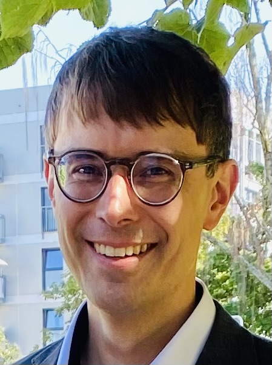

Hi! I am Martin Papenberg. I am a post-doctoral researcher and coordinator at the [Department of Experimental Psychology](https://www.psychologie.hhu.de/studium-und-lehre-psychologie/institutskoordinator), and member of the [Center for Digital Medicine](https://www.zdm.hhu.de/en/) at [Heinrich Heine University Düsseldorf](https://www.uni-duesseldorf.de/home/en/home.html). I am interested in statistics, methodology, measurement, and programming.

I am author of the `R` package [`anticlust`](https://github.com/m-Py/anticlust) that (among others) can be used to automatically assign stimuli to conditions in psychological experiments. The package website contains all documentation, introductory vignettes, and installation instructions. If you have any questions regarding the `anticlust` package, feel free to send me an email.

### Preprints

Tran, N. K., Mu, L., **Papenberg, M.**, & Klau, G. W. (2026). Coloring for dispersion: A polynomial-time algorithm for cardinality-constrained 2-anticlustering. *arXiv preprint*. https://doi.org/10.48550/arXiv.2604.24285

Angelike, T., & **Papenberg, M.** (2025). Preventing Dataset Shift During Cross-Validation: Is it worth it? *OSF Preprints*. https://doi.org/10.31219/osf.io/b5fus_v1

### Journal publications

**Papenberg, M.**, & Angelike, T. (2026). A simulation-based comparison of minimization, rerandomization, and anticlustering for creating experimental conditions. *Methodology, 22*(2), 127–150. https://doi.org/10.5964/meth.17973 ([Accepted Author Version](https://doi.org/10.23668/psycharchives.21773)) ([Preprint](https://doi.org/10.31234/osf.io/dpcyf_v2))

**Papenberg, M.**, Breuer, M., Diekhoff, M., Tran, N. K., & Klau, G. W. (2025). Extending the Bicriterion Approach for Anticlustering: Exact and Hybrid Approaches. *Psychometrika, 90*(5), 1789–1808. https://doi.org/10.1017/psy.2025.10052 ([Preprint](https://osf.io/a5r4y))

**Papenberg, M.**, Wang, C., Diop, M., Bukhari, S. H., Oskotsky, B., Davidson, B. R., Vo, K. C., Liu, B., Irwin, J. C., Combes, A., Gaudilliere, B., Li, J., Stevenson, D. K., Klau, G. W., Giudice, L. C., Sirota, M., & Oskotsky, T. T. (2025). Anticlustering for sample allocation to minimize batch effects. *Cell Reports Methods, 5*(8), 101137. https://doi.org/10.1016/j.crmeth.2025.101137 ([Preprint](https://doi.org/10.1101/2025.03.03.641320))

**Papenberg, M.** (2024). K-plus Anticlustering: An Improved k-means Criterion for Maximizing Between-Group Similarity. *British Journal of Mathematical and Statistical Psychology, 77*(1), 80–102. https://doi.org/10.1111/bmsp.12315 ([Preprint](https://doi.org/10.31234/osf.io/7jw6v))

Brandenburg, N., & **Papenberg, M.** (2024). Reassessment of innovative methods to determine the number of factors: A simulation-based comparison of exploratory graph analysis and next eigenvalue sufficiency test. *Psychological Methods, 29*(1), 21–47. https://doi.org/10.1037/met0000527 ([Preprint](https://doi.org/10.31234/osf.io/dhzrc))

**Papenberg, M.**, & Klau, G. W. (2021). Using anticlustering to partition data sets into equivalent parts. *Psychological Methods, 26*(2), 161–174. https://doi.org/10.1037/met0000301. ([Preprint](https://doi.org/10.31234/osf.io/3razc))

**Papenberg, M.**, Diedenhofen, B., & Musch, J. (2021). An experimental validation of sequential multiple-choice tests. *The Journal of Experimental Education, 89*(2), 402–421. https://doi.org/10.1080/00220973.2019.1671299 ([Preprint](https://osf.io/x8753/))

**Papenberg, M.**, & Musch, J. (2017). Of Small Beauties and Large Beasts: The Quality of Distractors on Multiple-Choice Tests Is More Important Than Their Quantity. *Applied Measurement in Education, 30*(4), 273–286. https://doi.org/10.1080/08957347.2017.1353987 ([Preprint](https://osf.io/xytfw/))

**Papenberg, M.**, Willing, S., & Musch, J. (2017). Sequentially Presented Response Options Prevent The Use Of Testwiseness Cues In Multiple-Choice Testing. *Psychological Test and Assessment Modeling, 59*(2), 245–266. ([Paper](http://www.psychologie-aktuell.com/fileadmin/download/ptam/2-2017_20170627/06_Papenberg_.pdf))

### Other Publications

Papenberg, M. (2018). *On how testwiseness and acceptance reluctance influence the validity of sequential knowledge tests* (Inaugural-Dissertation). Retrieved from https://docserv.uni-duesseldorf.de/servlets/DocumentServlet?id=46569

Papenberg, M. (2018). *Test theory in R* [Testtheorie mit R]. Retrieved from https://osf.io/nghyv/

### Software

- [anticlust: Subset Partitioning via Anticlustering](https://github.com/m-Py/anticlust)
- [propint: An R package to compute interactions in proportions](https://github.com/m-Py/propint)
- [cower: An R package for power analyses of the comparison of correlations](https://github.com/m-Py/cower)
- [prmisc: An R package to print statistical results in R markdown](https://github.com/m-Py/prmisc)
- [bayesEd: An educational R package to visualize Bayes factors](https://github.com/m-Py/bayesEd)
- [BART: A JavaScript implementation of the Balloon Analogue Risk Task](https://github.com/m-Py/BART)

### Academic CV

| Year |  |
| --- | --- |
| 2018 | Ph.D. (Dr. rer. nat), Faculty of Mathematics and Natural Sciences, Heinrich Heine University Düsseldorf |
| 2018 | B.Sc., Computer Science, Heinrich Heine University Düsseldorf |
| 2013 | M.Sc., Psychology, Heinrich Heine University Düsseldorf |
| 2011 | B.Sc., Psychology, Heinrich Heine University Düsseldorf |

### Contact

- Send me an email
- [Github](https://github.com/m-Py)
- [Google Scholar](https://scholar.google.de/citations?user=_h33JecAAAAJ&hl=de&oi=sra)
- [Mastodon](https://fosstodon.org/@MPapenberg)
- [Open Science Framework](https://osf.io/3gq2h)